# Predict the Manner of Excercise in Wearable Devices’ Data

## Synopsis

Using wearable devices it is now possible to collect a large amount of data about personal activity relatively inexpensively. In this report, we analyze the collected data and find a way to predict the manner in which they did the exercise. This is the “classe” variable in the training set. We divide our training data into training set and validation set. Then use ‘caret’ packages to build a model with **Generalized Boosted Regression** modeling. This built model is applied to validation set to see it validity. We also use our prediction model to predict 20 different test cases.

## Data Processing

### Loading R-packages and read data from csv files.

```r
# Loading necessary R packages
library(caret)
library(gbm)

# Use multi-cores to speed up data processing
library(parallel)
library(doParallel)

# set seed to make this report reproducible
set.seed(12345)

# read data from files
train <- read.csv("pml-training.csv", stringsAsFactors = FALSE)
test <- read.csv("pml-testing.csv", stringsAsFactors = FALSE)

# convert 'classe' field to factor since this prediction is classification,
# not regression.
train$classe <- as.factor(train$classe)
```

### Cleaning data and divide them into training set and validation set

```r
# We perform data cleaning operation to remove aggregation fields having name
# like max, avg, stdev .... etc.
usefields <-
  c("roll_belt", "pitch_belt", "yaw_belt", "total_accel_belt",
    "gyros_belt_x", "gyros_belt_y", "gyros_belt_z",
    "accel_belt_x", "accel_belt_y", "accel_belt_z",
    "magnet_belt_x", "magnet_belt_y", "magnet_belt_z",
    "roll_arm", "pitch_arm", "yaw_arm", "total_accel_arm",
    "gyros_arm_x", "gyros_arm_y", "gyros_arm_z",
    "accel_arm_x", "accel_arm_y", "accel_arm_z",
    "magnet_arm_x", "magnet_arm_y", "magnet_arm_z",
    "roll_dumbbell", "pitch_dumbbell", "yaw_dumbbell", "total_accel_dumbbell",
    "gyros_dumbbell_x", "gyros_dumbbell_y", "gyros_dumbbell_z",
    "accel_dumbbell_x", "accel_dumbbell_y", "accel_dumbbell_z",
    "magnet_dumbbell_x", "magnet_dumbbell_y", "magnet_dumbbell_z",
    "roll_forearm", "pitch_forearm", "yaw_forearm", "total_accel_forearm",
    "gyros_forearm_x", "gyros_forearm_y", "gyros_forearm_z",
    "accel_forearm_x", "accel_forearm_y", "accel_forearm_z",
    "magnet_forearm_x", "magnet_forearm_y", "magnet_forearm_z",
    "classe"
  )

# Split training data into training set (80%) and validation set (20%)
trainsetPercentage = 0.8
inTrain = createDataPartition(train$classe, p = trainsetPercentage)[[1]]

# Separate training data to traing set and validation set
trainset <- train[inTrain, usefields]
validset <- train[-inTrain, usefields]
```

### Use Generalized Boosted Regression Modeling to fit the training data

```r
# Training Control :
# We use repeated K-folds cross-validation, K = 0, repeat 3 times.

fitCtrl <- trainControl(
  method = "repeatedcv", number = 10, repeats = 3,
  verboseIter = FALSE,
  allowParallel = TRUE
)

# Use 'parallel' and 'doParallel' packages for multi-cores
cluster <- makeCluster(detectCores() - 1) # convention to leave 1 core for OS
registerDoParallel(cluster)

# We use stochastic gradient descent model for training.
system.time(
  gbm_model <-
    train(classe ~ ., data = trainset, method = "gbm", trControl = fitCtrl, verbose =  FALSE)
)
```

```
##    user  system elapsed
##   63.18    0.79 2356.29
```

```r
# Stop parallel functionality
stopCluster(cluster)
```

## Results

Now we have the following prediction model.

```r
gbm_model
```

[output not shown]

The importance of variables in our prediction model :

```r
library(caret)

varImp(gbm_model)
```

```
## gbm variable importance
##
##   only 20 most important variables shown (out of 52)
##
##                   Overall
## roll_belt         100.000
## pitch_forearm      50.724
## yaw_belt           39.036
## magnet_dumbbell_z  30.123
## magnet_dumbbell_y  24.513
## roll_forearm       23.912
## magnet_belt_z      16.296
## pitch_belt         15.348
## roll_dumbbell      14.651
## gyros_belt_z       12.659
## accel_dumbbell_y   10.329
## accel_forearm_x     9.985
## gyros_dumbbell_y    8.785
## accel_dumbbell_x    7.690
## yaw_arm             7.079
## magnet_dumbbell_x   7.061
## magnet_forearm_z    6.866
## accel_forearm_z     6.758
## magnet_belt_y       6.236
## magnet_arm_z        5.768
```

Then we draw the most important 4 features’ plot for each excercise manner variable, i.e. classe.

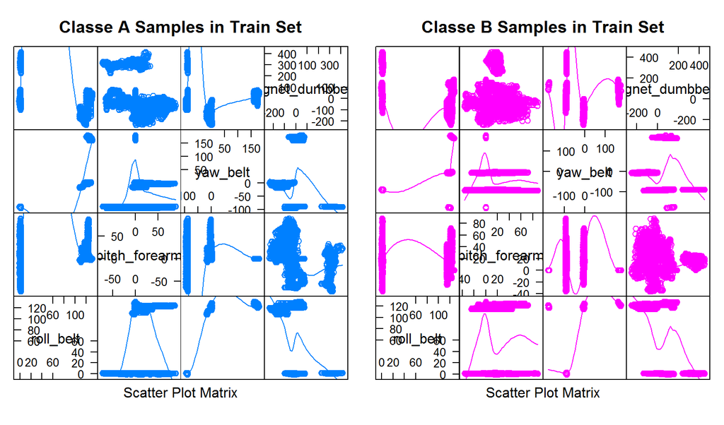

```r
library(gridExtra)

Aplot <- featurePlot(x = trainset[trainset$classe == 'A', c("roll_belt", "pitch_forearm", "yaw_belt", "magnet_dumbbell_z")],
            y = trainset$classe[trainset$classe == 'A'],
            plot = "pairs", type = c("p", "smooth"), span = .5,
            main = "Classe A Samples in Train Set")

Bplot <- featurePlot(x = trainset[trainset$classe == 'B', c("roll_belt", "pitch_forearm", "yaw_belt", "magnet_dumbbell_z")],
            y = trainset$classe[trainset$classe == 'B'],
            plot = "pairs", type = c("p", "smooth"), span = .5,
            main = "Classe B Samples in Train Set")

Cplot <- featurePlot(x = trainset[trainset$classe == 'C', c("roll_belt", "pitch_forearm", "yaw_belt", "magnet_dumbbell_z")],
            y = trainset$classe[trainset$classe == 'C'],
            plot = "pairs", type = c("p", "smooth"), span = .5,
            main = "Classe C Samples in Train Set")

Dplot <- featurePlot(x = trainset[trainset$classe == 'D', c("roll_belt", "pitch_forearm", "yaw_belt", "magnet_dumbbell_z")],
            y = trainset$classe[trainset$classe == 'D'],
            plot = "pairs", type = c("p", "smooth"), span = .5,
            main = "Classe D Samples in Train Set")

Eplot <- featurePlot(x = trainset[trainset$classe == 'E', c("roll_belt", "pitch_forearm", "yaw_belt", "magnet_dumbbell_z")],
            y = trainset$classe[trainset$classe == 'E'],
            plot = "pairs", type = c("p", "smooth"), span = .5,
            main = "Classe E Samples in Train Set")

grid.arrange(Aplot, Bplot, ncol=2)
```

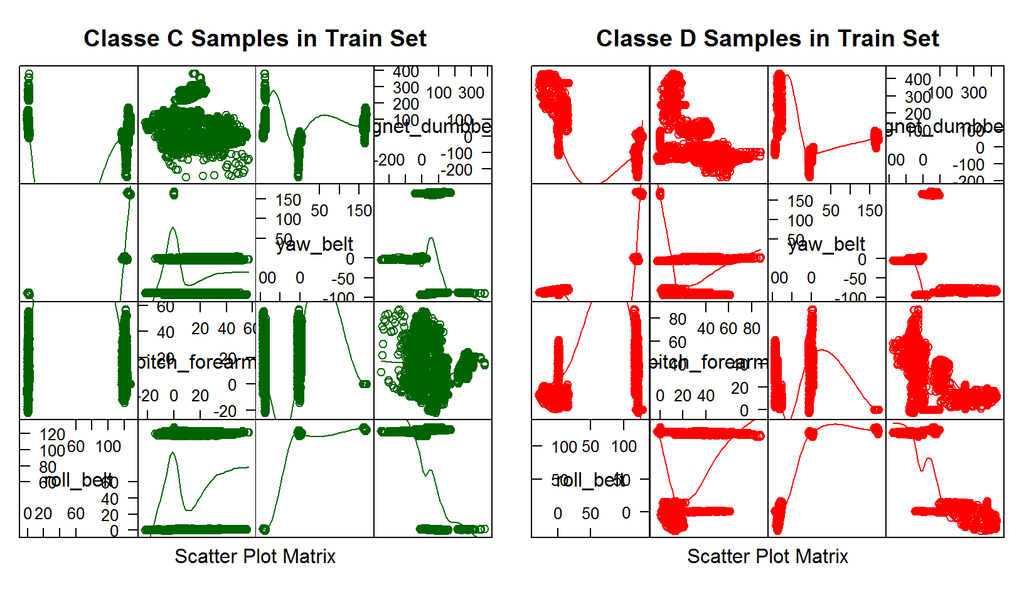

```r
grid.arrange(Cplot, Dplot, ncol=2)
```

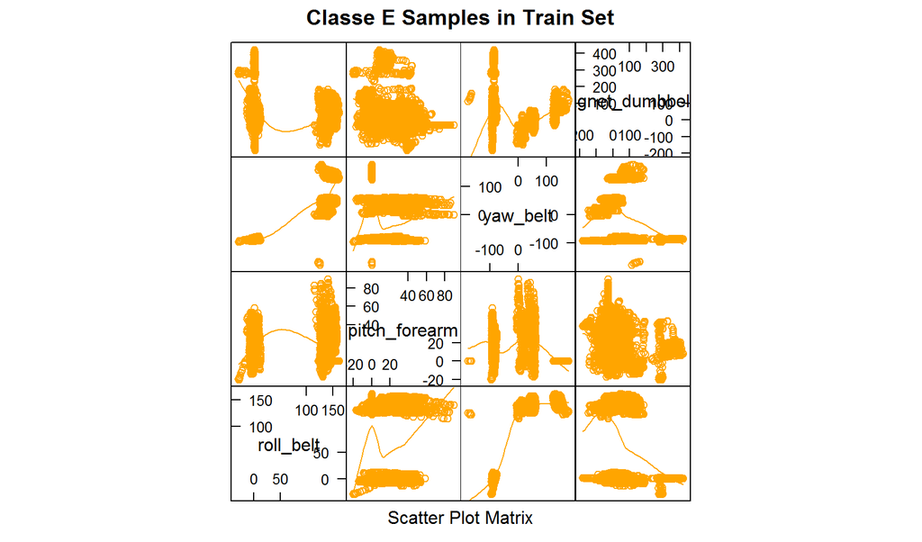

```r
grid.arrange(Eplot, ncol=1)
```

## Validation of Prediction Model

We then use this model to validate the validation set.

```r
validset_prediction <- predict(gbm_model, validset)
precision_rate <- sum(validset_prediction == validset$classe) / length(validset$classe)
precision_rate
```

```
## [1] 0.9732348
```

The precision rate is 0.9732348.

## Predicting 20 Test Cases

At the final step, we apply our model to 20 different test cases.

```r
predict(gbm_model, test)
```

```
##  [1] B A B A A E D B A A B C B A E E A B B B
## Levels: A B C D E
```